```r
library(tidyverse)
library(dplyr)
library(lubridate)
library(lattice)
library(rmarkdown)
```

```r
data = read.table("activity.csv",
                  sep = ",",
                  header = TRUE
                  ) %>%
        mutate(date = ymd(date)) %>%
        na.omit() %>%
        mutate(day.of.the.week = weekdays(date),
               Weekend = ifelse(day.of.the.week == "Saturday" | day.of.the.week == "Sunday", "Weekend", "Weekday")
        )
```

Q: What is mean total number of steps taken per day?

```r
avgDataByDate = data %>%
        group_by(date) %>%
        summarize(Total = sum(steps),
                  Average = mean(steps),
                  Median = median(steps)
        ) %>%
        mutate(Group = "Original")

text01 = paste("The total number of steps taken per day is stored in the table")
text02 = paste("The average and median steps taken per day is stored in the table")
print(text01)
```

[output not shown]

```r
print(text02)
```

[output not shown]

Assignment: If you do not understand the difference between a histogram and a barplot, research the difference between them. Make a histogram of the total number of steps taken each day

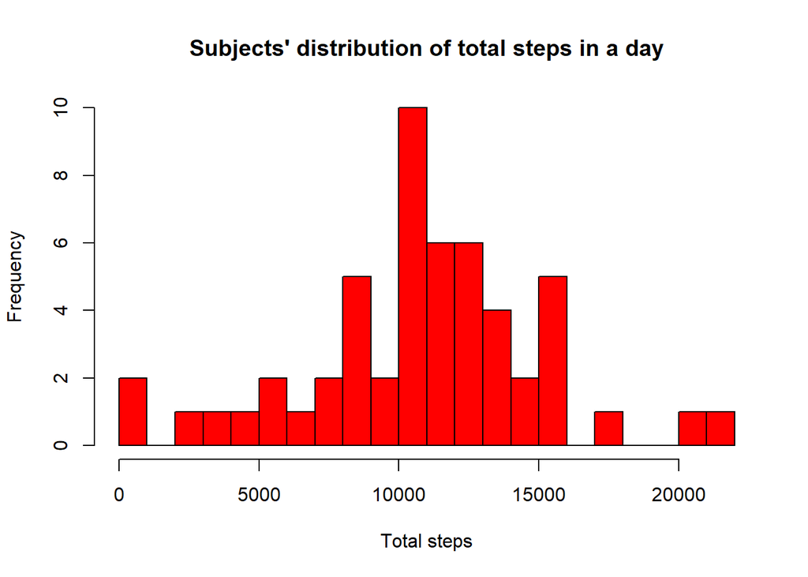

```r
hist(avgDataByDate$Total,
     main = "Subjects' distribution of total steps in a day",
     breaks = 20,
     col = "red",
     xlab = "Total steps",
     ylab = "Frequency",
     )
```

Question: What is the average daily activity pattern?

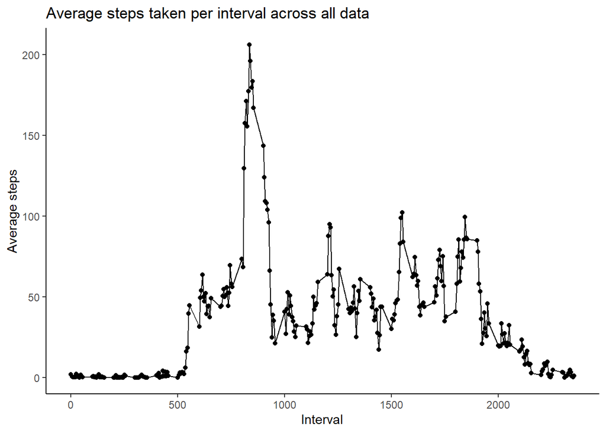

```r
test = data %>%
        group_by(interval) %>%
        summarize(total = sum(steps),
                  "Total Reads" = length(steps),
                  Minimum = min(steps),
                  Q1 = quantile(steps, 0.25),
                  Average = mean(steps),
                  Median = median(steps),
                  Q3 = quantile(steps, 0.75),
                  Maximum = max(steps))

x = ggplot(NULL, aes(y = test$Average, x = test$interval))
x + geom_line() + geom_point() +
        labs(x = "Interval",
             y = "Average steps",
             title = "Average steps taken per interval across all data") +
        theme_classic()
```

Question Which 5-minute interval, on average across all the days in the dataset, contains the maximum number of steps?

```r
intervalWithMaxSteps = test %>% filter(Average == max(test$Average))
intervalWithMaxSteps = intervalWithMaxSteps$interval

text  <-  paste("The 5 minute interval with the highest average number of steps on average is", intervalWithMaxSteps)
print(text)
```

```
## [1] "The 5 minute interval with the highest average number of steps on average is 835"
```

Question: Imputing missing values Note that there are a number of days/intervals where there are missing values (coded as NA). The presence of missing days may introduce bias into some calculations or summaries of the data.

```r
rowsNA = read.table("activity.csv",
                  sep = ",",
                  header = TRUE
                  ) %>%
        filter_all(any_vars(is.na(.)))

numOfRowsNA = dim(rowsNA)[1]
numOfRowsNA = paste("The total number of missing values in the dataset is", numOfRowsNA)
print(numOfRowsNA)
```

```
## [1] "The total number of missing values in the dataset is 2304"
```

```r
#fill in average value for that day
newData = read.table("activity.csv",
                  sep = ",",
                  header = TRUE
                  ) %>%
        mutate(date = ymd(date))

for (i in 1:length(newData$steps)) {

        if(is.na(newData$steps[i])) {

                newData$steps[i] = mean(avgDataByDate$Average)

        }

}
```

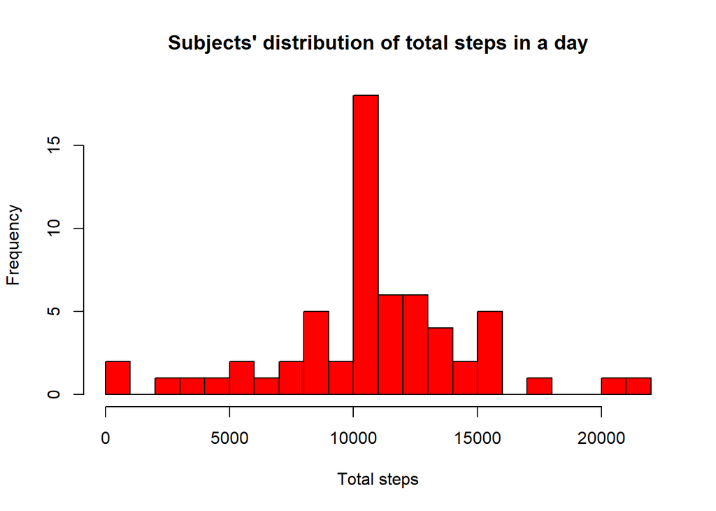

```r
avgNewDataByDate = newData %>%
        na.omit() %>%
        group_by(date) %>%
        summarize(Total = sum(steps),
                  Average = mean(steps),
                  Median = median(steps)
        ) %>%
        mutate(Group = "Altered")

hist(avgNewDataByDate$Total,
     main = "Subjects' distribution of total steps in a day",
     breaks = 20,
     col = "red",
     xlab = "Total steps",
     ylab = "Frequency",
     )
```